# kNN parameter exploration for classifying country status using life expectancy data

Wong, Courtney

2024-10-05

```r
suppressPackageStartupMessages({
  library(tidyverse)
  library(knitr)
  library(Hmisc)
  library(reshape2)
  library(class)
})
```

# Data Understanding

## Exploration

Below, we import and explore the life expectancy data provided by the WHO (LifeExpectancyData.csv) using various methods and make some observations:

- Confirm correct data import by viewing the first 5 observations with `head()`.
- Inspect the structure of the data such as data types and values with `str()`. Of the 22 features, only 2 are non-numeric.
- Inspect the distribution of each feature, excluding the country name, using `hist.data.frame()` from `Hmisc`. There is a wide variety in distributions among the different features. Few appear to be normal.
- Inspect the number and percent of missing values for each feature, arranged in decreasing order. There are 7 features with more than 5% of the data missing.
- Inspect pairs of features with a Spearman correlation coefficient greater than 0.8, arranged in decreasing order. There are 8 pairs that appear to be correlated.

```r
# Import CSV
df <- read.csv("https://s3.us-east-2.amazonaws.com/artificium.us/datasets/LifeExpectancyData.csv",
               stringsAsFactors = FALSE)
# Inspect first 5 rows
head(df, n=5)
```

|  | Country | Year | Status | Life.expectancy | Adult.Mortality | infant.deaths | Alcohol | percentage.expenditure | Hepatitis.B | Measles | BMI | under.five.deaths | Polio | Total.expenditure | Diphtheria | HIV.AIDS | GDP | Population | thinness..1.19.years | thinness.5.9.years | Income.composition.of.resources | Schooling |
| --- | --- | --- | --- | --- | --- | --- | --- | --- | --- | --- | --- | --- | --- | --- | --- | --- | --- | --- | --- | --- | --- | --- |
| 1 | Afghanistan | 2015 | Developing | 65.0 | 263 | 62 | 0.01 | 71.279624 | 65 | 1154 | 19.1 | 83 | 6 | 8.16 | 65 | 0.1 | 584.25921 | 33736494 | 17.2 | 17.3 | 0.479 | 10.1 |
| 2 | Afghanistan | 2014 | Developing | 59.9 | 271 | 64 | 0.01 | 73.523582 | 62 | 492 | 18.6 | 86 | 58 | 8.18 | 62 | 0.1 | 612.69651 | 327582 | 17.5 | 17.5 | 0.476 | 10.0 |
| 3 | Afghanistan | 2013 | Developing | 59.9 | 268 | 66 | 0.01 | 73.219243 | 64 | 430 | 18.1 | 89 | 62 | 8.13 | 64 | 0.1 | 631.74498 | 31731688 | 17.7 | 17.7 | 0.470 | 9.9 |
| 4 | Afghanistan | 2012 | Developing | 59.5 | 272 | 69 | 0.01 | 78.184215 | 67 | 2787 | 17.6 | 93 | 67 | 8.52 | 67 | 0.1 | 669.95900 | 3696958 | 17.9 | 18.0 | 0.463 | 9.8 |
| 5 | Afghanistan | 2011 | Developing | 59.2 | 275 | 71 | 0.01 | 7.097109 | 68 | 3013 | 17.2 | 97 | 68 | 7.87 | 68 | 0.1 | 63.53723 | 2978599 | 18.2 | 18.2 | 0.454 | 9.5 |

```r
# Inspect the structure
str(df)
```

```
## 'data.frame':    2938 obs. of  22 variables:
##  $ Country                        : chr  "Afghanistan" "Afghanistan" "Afghanistan" "Afghanistan" ...
##  $ Year                           : int  2015 2014 2013 2012 2011 2010 2009 2008 2007 2006 ...
##  $ Status                         : chr  "Developing" "Developing" "Developing" "Developing" ...
##  $ Life.expectancy                : num  65 59.9 59.9 59.5 59.2 58.8 58.6 58.1 57.5 57.3 ...
##  $ Adult.Mortality                : int  263 271 268 272 275 279 281 287 295 295 ...
##  $ infant.deaths                  : int  62 64 66 69 71 74 77 80 82 84 ...
##  $ Alcohol                        : num  0.01 0.01 0.01 0.01 0.01 0.01 0.01 0.03 0.02 0.03 ...
##  $ percentage.expenditure         : num  71.3 73.5 73.2 78.2 7.1 ...
##  $ Hepatitis.B                    : int  65 62 64 67 68 66 63 64 63 64 ...
##  $ Measles                        : int  1154 492 430 2787 3013 1989 2861 1599 1141 1990 ...
##  $ BMI                            : num  19.1 18.6 18.1 17.6 17.2 16.7 16.2 15.7 15.2 14.7 ...
##  $ under.five.deaths              : int  83 86 89 93 97 102 106 110 113 116 ...
##  $ Polio                          : int  6 58 62 67 68 66 63 64 63 58 ...
##  $ Total.expenditure              : num  8.16 8.18 8.13 8.52 7.87 9.2 9.42 8.33 6.73 7.43 ...
##  $ Diphtheria                     : int  65 62 64 67 68 66 63 64 63 58 ...
##  $ HIV.AIDS                       : num  0.1 0.1 0.1 0.1 0.1 0.1 0.1 0.1 0.1 0.1 ...
##  $ GDP                            : num  584.3 612.7 631.7 670 63.5 ...
##  $ Population                     : num  33736494 327582 31731688 3696958 2978599 ...
##  $ thinness..1.19.years           : num  17.2 17.5 17.7 17.9 18.2 18.4 18.6 18.8 19 19.2 ...
##  $ thinness.5.9.years             : num  17.3 17.5 17.7 18 18.2 18.4 18.7 18.9 19.1 19.3 ...
##  $ Income.composition.of.resources: num  0.479 0.476 0.47 0.463 0.454 0.448 0.434 0.433 0.415 0.405 ...
##  $ Schooling                      : num  10.1 10 9.9 9.8 9.5 9.2 8.9 8.7 8.4 8.1 ...
```

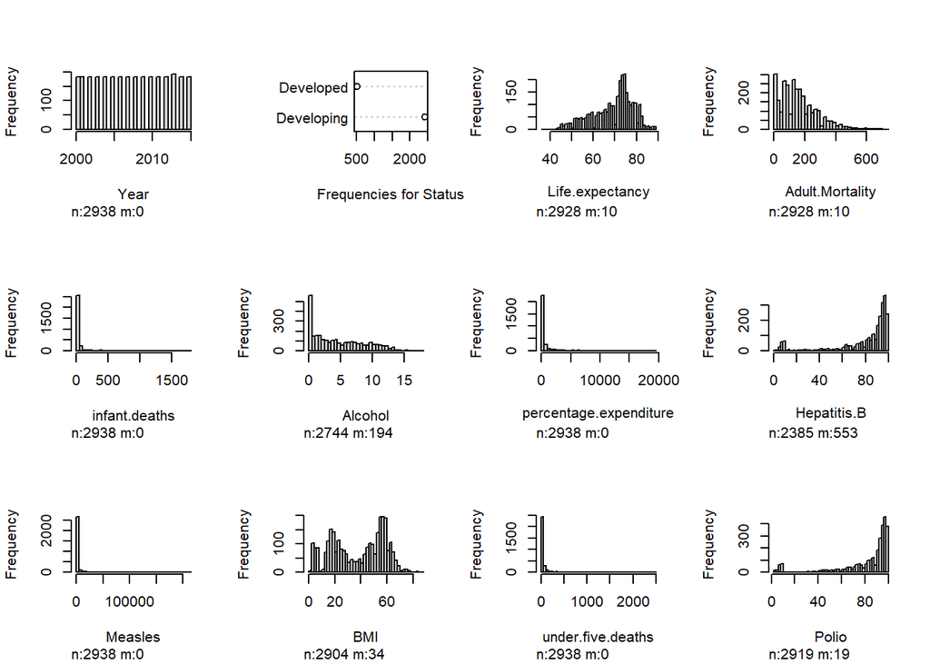

```r
# Inspect the distribution, exclude country name
hist.data.frame(df[2:13], n.unique=2)
```

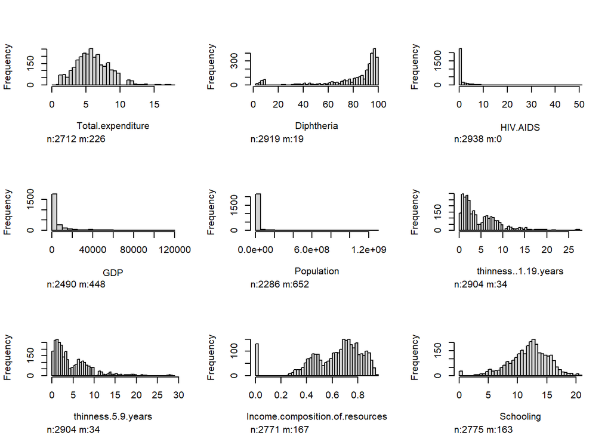

```r
hist.data.frame(df[14:22], n.unique=2)
```

```r
# Check for missing values
missing <- apply(df, MARGIN=2, function(x) sum(is.na(x))) %>%
  as.data.frame() %>%
  rename(NumMissing = 1) %>%
  mutate(PctMissing = NumMissing / nrow(df) * 100) %>%
  arrange(-PctMissing)
kable(missing)
```

|  | NumMissing | PctMissing |
| --- | --- | --- |
| Population | 652 | 22.1919673 |
| Hepatitis.B | 553 | 18.8223281 |
| GDP | 448 | 15.2484683 |
| Total.expenditure | 226 | 7.6923077 |
| Alcohol | 194 | 6.6031314 |
| Income.composition.of.resources | 167 | 5.6841389 |
| Schooling | 163 | 5.5479918 |
| BMI | 34 | 1.1572498 |
| thinness..1.19.years | 34 | 1.1572498 |
| thinness.5.9.years | 34 | 1.1572498 |
| Polio | 19 | 0.6466984 |
| Diphtheria | 19 | 0.6466984 |
| Life.expectancy | 10 | 0.3403676 |
| Adult.Mortality | 10 | 0.3403676 |
| Country | 0 | 0.0000000 |
| Year | 0 | 0.0000000 |
| Status | 0 | 0.0000000 |
| infant.deaths | 0 | 0.0000000 |
| percentage.expenditure | 0 | 0.0000000 |
| Measles | 0 | 0.0000000 |
| under.five.deaths | 0 | 0.0000000 |
| HIV.AIDS | 0 | 0.0000000 |

```r
# Inspect pairs whose spearman correlation > 0.8
cor(df[c(-1,-2,-3)], use="pairwise.complete.obs", method="spearman") %>%
  melt() %>%
  filter(value > 0.8 | value < -0.8,
         Var1 != Var2) %>%
  group_by(value) %>%
  slice_head(n=1) %>%
  arrange(-abs(value)) %>%
  rename(SpearmanCor = value) %>%
  kable()
```

| Var1 | Var2 | SpearmanCor |
| --- | --- | --- |
| under.five.deaths | infant.deaths | 0.9932012 |
| thinness.5.9.years | thinness..1.19.years | 0.9470423 |
| Diphtheria | Polio | 0.9210708 |
| Schooling | Income.composition.of.resources | 0.9005297 |
| Income.composition.of.resources | Life.expectancy | 0.8657015 |
| Diphtheria | Hepatitis.B | 0.8173095 |
| Schooling | Life.expectancy | 0.8135410 |
| GDP | percentage.expenditure | 0.8067070 |

To further investigate the missing values, we check the distribution of the features with more than 10% missing, colored by the feature we wish to build a predictive model for (Country Status).

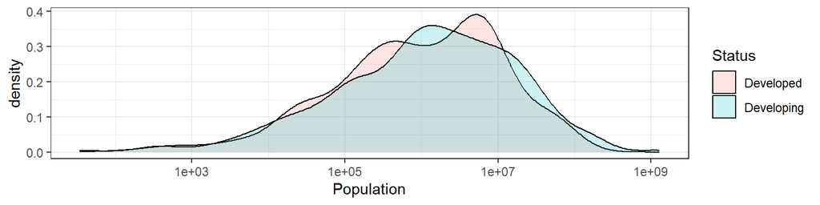

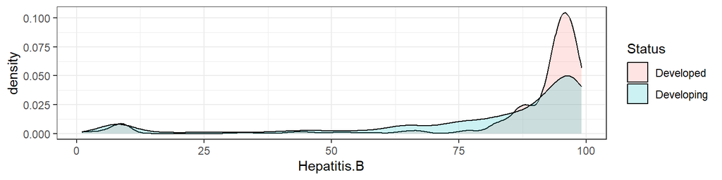

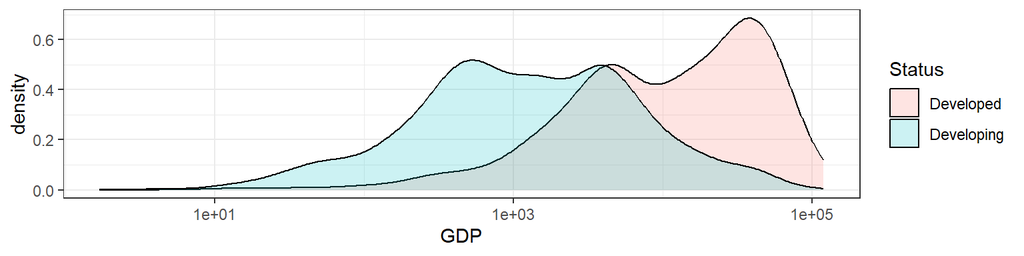

```r
map(rownames(missing[missing$PctMissing>10,]), ~ {
  g <- df %>%
    ggplot(aes(x=!!sym(.x), fill=Status)) +
    geom_density(alpha=.2) +
    theme_bw()
  if (.x %in% c("Population", "GDP")) {
    g + scale_x_log10()
  } else {
    g
  }
})
```

The dependency of these features on the target variable is taken into account in the next phase when we prepare the data.

# Data Preparation

## Imputation of Missing Values

Since Hepatitis and GDP appear extremely dependent on Country status, we decide to impute the median by country status. Otherwise, the value would be skewed toward whichever status is more represented (developing countries are 4x more represented than developed countries), and this would negatively impact the predictive power of the model. We impute Population with median normally. We choose the median instead of the mean to be less skewed by outliers. Lastly, as we have a decently large dataset, we can afford to omit the remaining observations with a missing value.

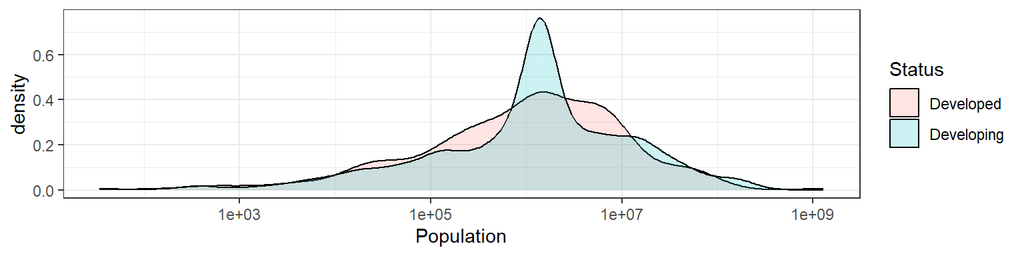

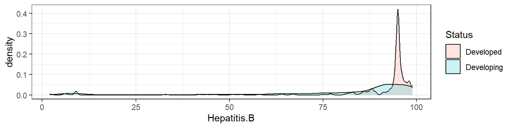

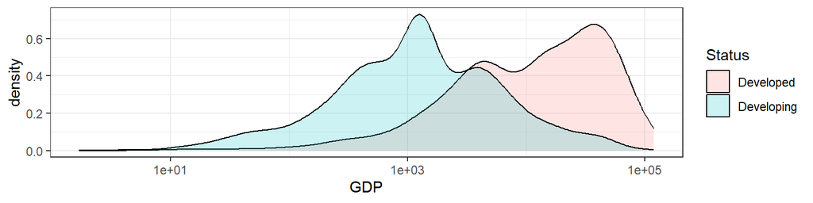

```r
df <- df %>%
  # Impute population to overall median
  mutate(Population = ifelse(is.na(Population), median(Population, na.rm=TRUE), Population)) %>%
  # Impute the rest by median within country status
  group_by(Status) %>%
  mutate(Hepatitis.B = ifelse(is.na(Hepatitis.B), median(Hepatitis.B, na.rm=TRUE), Hepatitis.B),
         GDP = ifelse(is.na(GDP), median(GDP, na.rm=TRUE), GDP),
         Schooling = ifelse(is.na(Schooling), median(Schooling, na.rm=TRUE), Schooling)) %>%
  # Exclude the rest, small portion of dataset
  na.omit

map(rownames(missing[missing$PctMissing>10,]), ~ {
  g <- df %>%
    ggplot(aes(x=!!sym(.x), fill=Status)) +
    geom_density(alpha=.2) +
    theme_bw()
  if (.x %in% c("Population", "GDP")) {
    g + scale_x_log10()
  } else {
    g
  }
})
```

The graphs above show the newly imputed dataset, understandably with a higher peak at the median value, but importantly the distinction between the two statuses are preserved. We are now left with 2556 datapoints after handling missing values.

## Derived Attribute for Per Capita Mortality

Next, we create a derived attribute for per capital mortality and compare the rate between Developing versus Developed countries. The source file represents adult deaths per 1000 and infant deaths in absolute count, so we calculate the per-capita mortality rate as follows: `Adult.Mortality/1000 + infant.deaths/Population`. Error bars represent mean +/- standard deviation within each country status group.

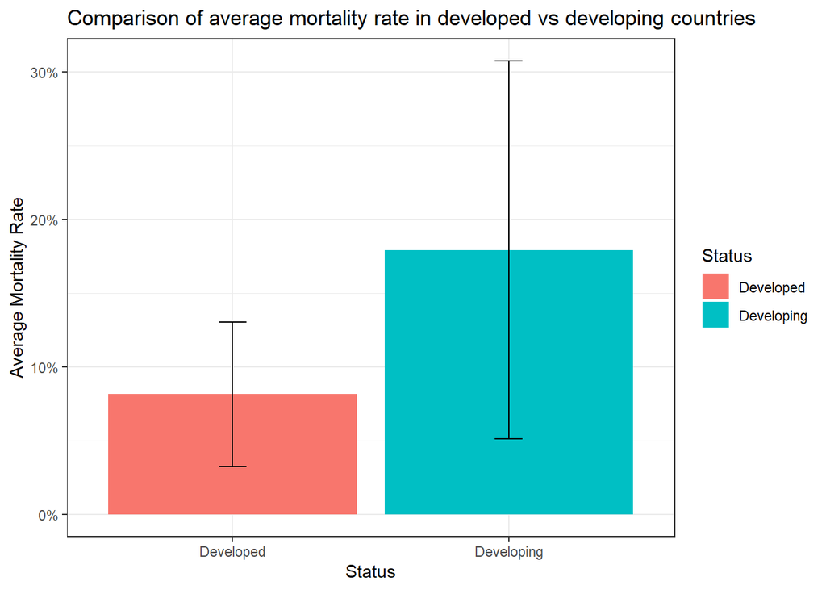

```r
# Calculate mortality per capita
df$Mortality.Rate = df$Adult.Mortality/1000 + df$infant.deaths/df$Population

df %>%
  # Descriptive statistics by Status type
  group_by(Status) %>%
  dplyr::summarize(Mortality.Rate_avg = mean(Mortality.Rate),
            Mortality.Rate_sd = sd(Mortality.Rate)) %>%
  ggplot(aes(x=Status, y=Mortality.Rate_avg, fill=Status)) +
  geom_bar(stat="identity") +
  geom_errorbar(aes(
    ymin = Mortality.Rate_avg - Mortality.Rate_sd,
    ymax = Mortality.Rate_avg + Mortality.Rate_sd,
    width=.1
  )) +
  theme_bw() +
  scale_y_continuous(labels = scales::percent) +
  labs(title = "Comparison of average mortality rate in developed vs developing countries",
         y = "Average Mortality Rate")
```

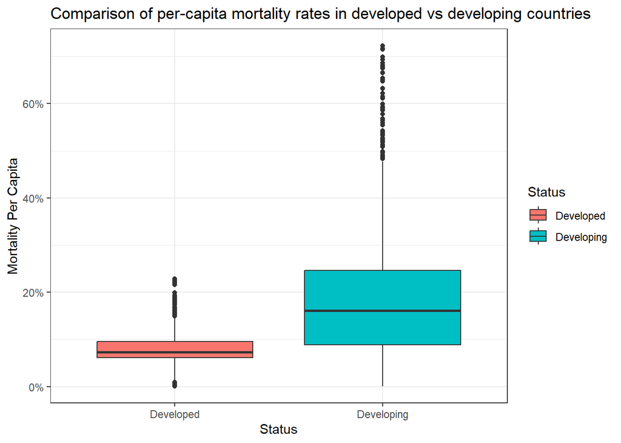

```r
df %>%
  ggplot(aes(x=Status, y=Mortality.Rate, fill=Status)) +
  geom_boxplot() +
  scale_y_continuous(labels = scales::percent) +
  theme_bw() +
  labs(title = "Comparison of per-capita mortality rates in developed vs developing countries",
         y = "Mortality Per Capita")
```

From both plots, we can observe that both the statistical mean and the median for Per Capita Mortality is higher in Developing countries than in Developed countries. This aligns with our pre-conceived notions about healthcare access in developed versus developing countries, but the noisiness of the data, as indicated by the long whiskers and large IQR in the second plot and the error bars in the first plot, prompts for further analysis to determine whether this difference is statistically significant.

To do this, we first check for normality both visually and with a test on both datasets, shown below.

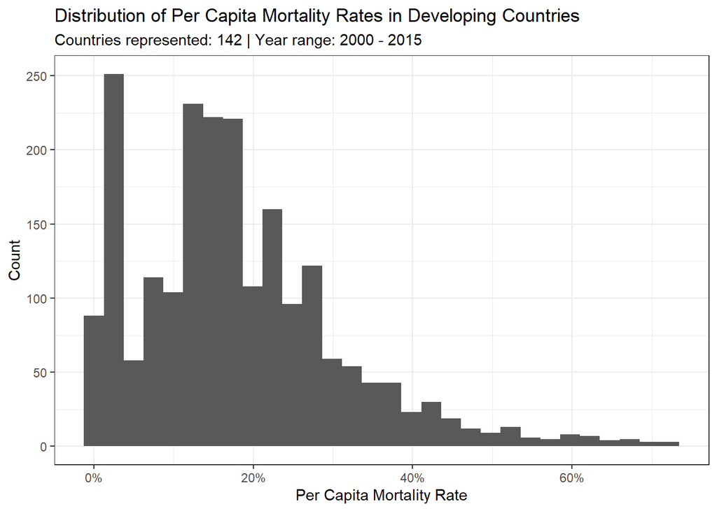

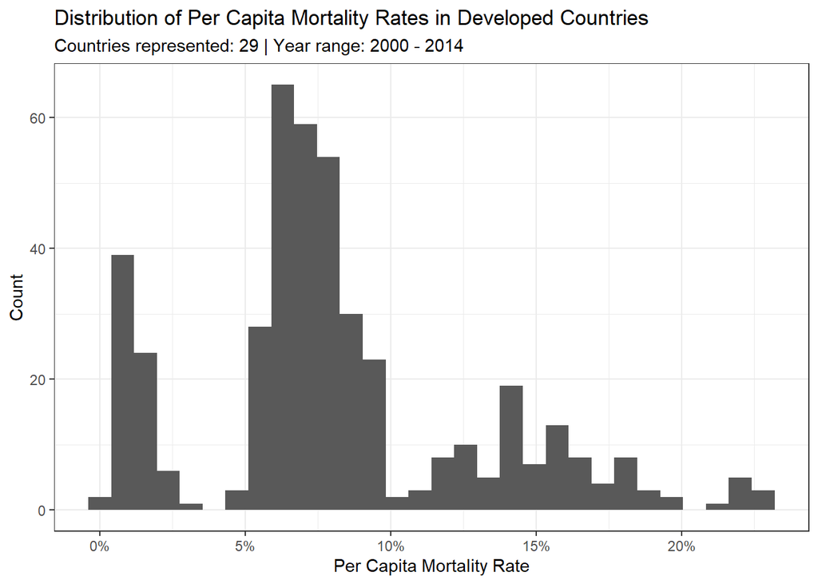

```r
map(unique(df$Status), ~ {
  df %>%
    filter(Status == .x) %>%
    ggplot(aes(x=Mortality.Rate)) +
    geom_histogram() +
    theme_bw() +
    scale_x_continuous(labels = scales::percent) +
    labs(title = paste("Distribution of Per Capita Mortality Rates in", .x, "Countries"),
         subtitle = paste("Countries represented:", n_distinct(filter(df, Status==.x)$Country),
                          "| Year range:", min(filter(df, Status==.x)$Year), "-",
                          max(filter(df, Status==.x)$Year)),
         x = "Per Capita Mortality Rate",
         y = "Count")
})
```

We use a Shapiro Wilk normality test below on both original and log-transformed mortality rates by country status to check for normality. The sample size is appropriate for this test as it is between 3 and 5000.

```r
t1 <- shapiro.test(df[df$Status=="Developing",]$Mortality.Rate)
t2 <- shapiro.test(df[df$Status=="Developed",]$Mortality.Rate)
t1
```

```
##
##  Shapiro-Wilk normality test
##
## data:  df[df$Status == "Developing", ]$Mortality.Rate
## W = 0.92642, p-value < 2.2e-16
```

```r
t2
```

```
##
##  Shapiro-Wilk normality test
##
## data:  df[df$Status == "Developed", ]$Mortality.Rate
## W = 0.92301, p-value = 3.891e-14
```

```r
t3 <- shapiro.test(log10(df[df$Status=="Developing",]$Mortality.Rate))
t4 <- shapiro.test(log10(df[df$Status=="Developed",]$Mortality.Rate))
t3
```

```
##
##  Shapiro-Wilk normality test
##
## data:  log10(df[df$Status == "Developing", ]$Mortality.Rate)
## W = 0.87263, p-value < 2.2e-16
```

```r
t4
```

```
##
##  Shapiro-Wilk normality test
##
## data:  log10(df[df$Status == "Developed", ]$Mortality.Rate)
## W = 0.81979, p-value < 2.2e-16
```

```r
t <- wilcox.test(df[df$Status=="Developing",]$Mortality.Rate,
            df[df$Status=="Developed",]$Mortality.Rate)
t
```

```
##
##  Wilcoxon rank sum test with continuity correction
##
## data:  df[df$Status == "Developing", ]$Mortality.Rate and df[df$Status == "Developed", ]$Mortality.Rate
## W = 701795, p-value < 2.2e-16
## alternative hypothesis: true location shift is not equal to 0
```

The test returns a p value of **6.2036371^{-66}**. With an alpha of 0.05, we reject the null hypothesis and conclude that per-capita mortality rates are indeed distributed differently in developing versus developed countries. This suggests it may be a useful feature for our kNN model.

## Identification of Outliers

Next, we analyze outliers in each column (excluding the Country name and Status which are non-numerical as well as the year). We define an outlier as any value with an absolute Z-score of greater than 2.8 (i.e. greater than 2.8 standard deviations from the mean). We show all outliers below:

```r
index_outliers <- function(x) {
  x <- x[!is.na(x)]
  x_mean <- mean(x)
  x_sd <- sd(x)
  z_scores <- abs(x - x_mean) / x_sd
  # list("outliers" = x[z_scores > 2.8],
  #      "remaining" = x[z_scores <= 2.8],
  #      "indices" = z_scores > 2.8)
  return(z_scores > 2.8)
}
lapply(df[-c(1,2,3)], function(x) {x[index_outliers(x)]})
```

```
## $Life.expectancy
## [1] 36.3 42.3 41.5 41.0 39.0
##
## $Adult.Mortality
##  [1] 566 652 693 699 679 647 511 512 593 682 522 518 513 527 566 592 633 654 675
## [20] 666 648 622 586 543 525 559 587 615 613 599 588 513 519 533 564 587 568 536
## [39] 523 539 554 526 554 578 611 614 527 587 632 717 723 715 686 665
##
## $infant.deaths
##  [1]  391  422  457  490  957 1000 1100 1100 1200 1300 1300 1400 1500 1500 1600
## [16] 1700 1700 1800 1800  490  498  505  513  521  527  536  542  549  556  563
## [31]  567  571  574  576  377  385
##
## $Alcohol
## [1] 16.35 17.31 16.99 17.87 16.58
##
## $percentage.expenditure
##  [1] 10769.363 11734.854 11714.999 10986.265  8875.786  7172.275  8547.292
##  [8]  8350.194  7878.372  8272.307  7423.229  8053.558  8329.732  7453.864
## [15]  7163.349  7191.052  9733.228  9748.636  8649.675  8433.937  7946.744
## [22] 10468.763 10261.763 10251.109  9765.617 10761.182  9703.068  7627.412
## [29]  6948.840  7002.786  7584.079  7641.271  8285.265  7777.556  8254.021
## [36]  6818.546  7613.815 12042.974 10631.204  8506.101  7620.823  9528.231
## [43]  9797.553  9126.931  8040.220  9498.729  7313.175  6799.664 16255.162
## [50] 15515.752 17028.528 18961.349 15345.491 12372.052 10111.389  7877.337
## [57]  8246.130 10873.406  9689.733  8344.010 10019.076  8342.406  6761.289
## [64] 15268.064 14829.412 12829.254 11792.535  7971.646 10947.023 11477.667
## [71]  8105.591  7593.392 19479.912 19099.045 18379.330 18822.867 14714.826
## [78] 11892.334 10598.082 10055.350  9495.541  6853.628
##
## $Hepatitis.B
##   [1]  9  8  9  8  5  5  9 11  5 18  7  6  6  6  8  7 15  8  9  9  9  9  9  4  8
##  [26]  8  7  7 14 14 14 14 14  4 17  9  9  7  6  9  8  9  7  9  8  8  8  8  9  9
##  [51]  2  9  9  7  9  9  9  8  8  8  9  8  9  7  6  6  8  6  9  9  8  5  9  9  5
##  [76]  5  9  8  8  9  6 17  5  8  7  7  9  9  8  8  9  8  9  9  9  9  9  9  4  8
## [101]  9  2  2  2  9  9  9  9  7 18  7  8  8  6  6  9  7  7 14  6 12  7  9  9  8
## [126]  7  9  9  8  8  9  8  9  9  9  9  9  5  8  7  4  6  7  6  5  8 14  8  9  7
##
## $Measles
##  [1]  54118  52628  38159  52461 131441 109023  99602 124219  70549  71879
```

[output cut: 74 more lines]

```
##  [75] 0 0 0 0 0 0 0 0 0 0 0 0 0 0 0 0 0 0 0 0 0 0 0 0 0 0 0 0 0 0 0 0 0 0 0 0 0
## [112] 0 0 0
##
## $Schooling
##  [1] 0.0 0.0 0.0 0.0 0.0 0.0 0.0 2.9 2.9 0.0 0.0 3.0 2.9 2.9 2.8 0.0
##
## $Mortality.Rate
##  [1] 0.5660011 0.6520109 0.6930108 0.6990011 0.6790011 0.6470116 0.5110412
##  [8] 0.5123733 0.5930206 0.6820023 0.5220019 0.5180019 0.5130138 0.5271629
## [15] 0.5661824 0.5920250 0.6330020 0.6540025 0.6750026 0.6660026 0.6480261
## [22] 0.6220260 0.5860027 0.5430027 0.5250025 0.5590267 0.5870028 0.6150316
## [29] 0.6130035 0.5990041 0.5880045 0.5130061 0.5190063 0.5330064 0.5640267
## [36] 0.5885848 0.5680173 0.5360186 0.5230435 0.5390046 0.5540476 0.5260027
## [43] 0.5540272 0.5780031 0.6110236 0.6140287 0.5270195 0.5870217 0.6320022
## [50] 0.7172163 0.7230021 0.7150021 0.6860020 0.6650020
```

The table below summarizes the number and percent of each column that are outliers:

```r
outlier.summ <- lapply(df[-c(1,2,3)], function(x) { c(
  NumOutliers = length(x[index_outliers(x)]),
  PctOutliers = round(length(x[index_outliers(x)]) / length(x) * 100, 2)
  )}) %>%
  as.data.frame() %>%
  t() %>%
  as.data.frame() %>%
  arrange(-PctOutliers)
kable(outlier.summ)
```

|  | NumOutliers | PctOutliers |
| --- | --- | --- |
| Hepatitis.B | 150 | 5.87 |
| Polio | 142 | 5.56 |
| Diphtheria | 140 | 5.48 |
| Income.composition.of.resources | 114 | 4.46 |
| GDP | 94 | 3.68 |
| percentage.expenditure | 82 | 3.21 |
| HIV.AIDS | 71 | 2.78 |
| thinness.5.9.years | 62 | 2.43 |
| thinness..1.19.years | 59 | 2.31 |
| Adult.Mortality | 54 | 2.11 |
| Mortality.Rate | 54 | 2.11 |
| Measles | 44 | 1.72 |
| infant.deaths | 36 | 1.41 |
| under.five.deaths | 33 | 1.29 |
| Population | 22 | 0.86 |
| Schooling | 16 | 0.63 |
| Total.expenditure | 13 | 0.51 |
| Life.expectancy | 5 | 0.20 |
| Alcohol | 5 | 0.20 |
| BMI | 0 | 0.00 |

Only 3 features have more than 5% outliers: `Hepatitis.B`, `Polio`, and `Diphtheria`. All outlier values originate from the small peak on the far left of the distribution, shown below. Considering that both developed and developing countries have this small peak and that the key distinguishing feature is the far right of the curve, it is reasonable to remove these observations. We choose to leave the remaining outliers as they make up such a small proportion of the data and are unlikely to sway the general trend. Another option is imputation, but we believe it is ill-advised to fabricate values when values already exist, and our earlier imputation of missing values has already brought the data much closer to the median.

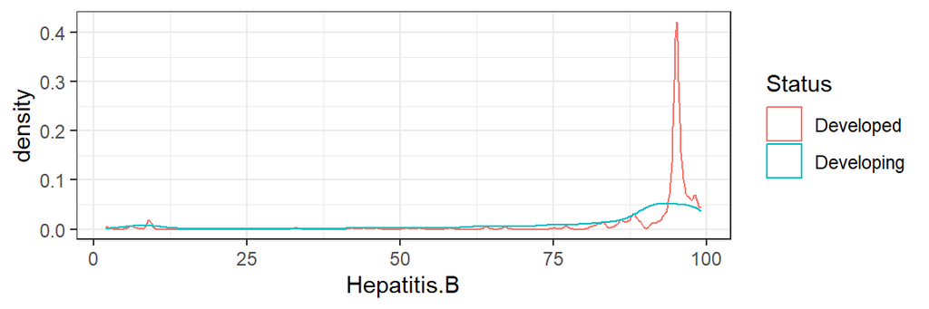

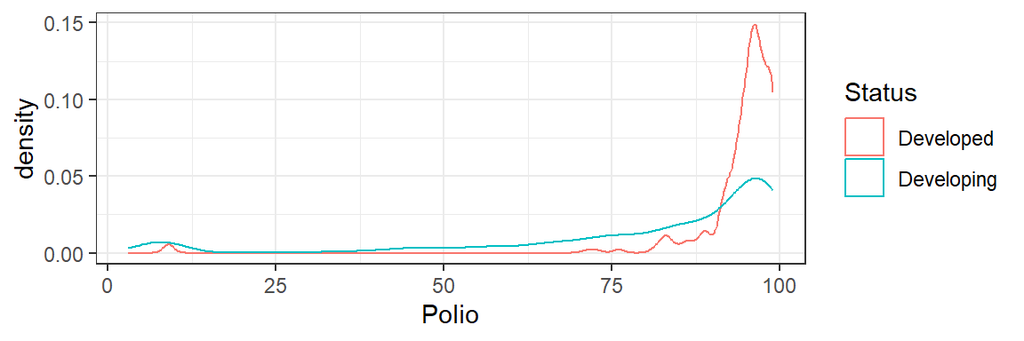

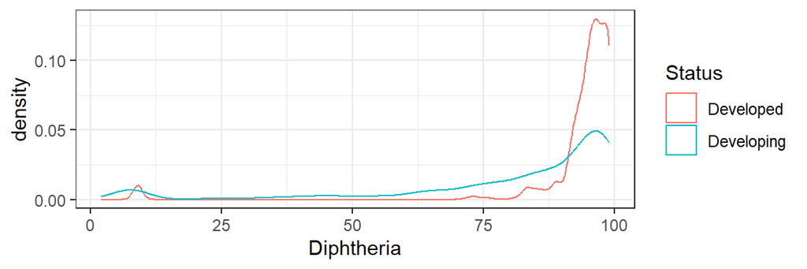

```r
map(rownames(outlier.summ[outlier.summ$PctOutliers>5,]), ~ {
  df %>%
  ggplot(aes(x=!!sym(.x), color=Status)) +
  geom_density() +
  theme_bw()
})
```

```r
mask <- lapply(df[c("Hepatitis.B", "Polio", "Diphtheria")], function(x) {index_outliers(x)}) # list of outlier logicals per feature
mask <- bind_rows(mask) # convert to dataframe
mask <- apply(mask, MARGIN=1, FUN=any) # check every row for an outlier in any feature
df <- df[!mask,]
```

To conclude, we have decided to eliminate observations with an outlier value for `Hepatitis.B`, `Polio`, or `Diphtheria` because these outliers constitute slightly greater than 5% of the column and do not appear to be very distinct in their distribution between developed vs developing countries. We have left the remaining outliers as they are small enough in number to have little impact on the overall trend. This leaves us with 2242 observations.

## Z-Score Normalization

In this next phase, we prepare the data first by normalizing all numeric columns (i.e. everything except Country name and Status) using Z-score standardization. This is an important step because we do not want values that are intrinsically higher in magnitude, such as a year (thousands) or population (in hundreds of thousands) to shadow values that are intrinsically lower in magnitude, such as a rate (between 0 and 1) or counts of cases. We accomplish this by using `lapply()` to normalize every column: subtract the column’s mean then divide by the column’s standard deviation.

```r
# Create function
normalize <- function(x) {
  (x-mean(x, na.rm=TRUE))/sd(x, na.rm=TRUE)
}
# Apply to dataframe
# NOTE: Exclude the id column and the diagnosis column
df.norm <- cbind(Country = df$Country,
                 Status = df$Status,
                 as.data.frame(lapply(df[,c(-1, -3)], normalize)))
```

## Derived Attribute for Disease

```r
df$Disease <- df$Hepatitis.B + df$Measles + df$Polio + df$HIV.AIDS + df$Diphtheria
df.norm$Disease <- normalize(df$Disease)
head(df.norm[c("Hepatitis.B", "Measles", "Polio", "HIV.AIDS", "Diphtheria", "Disease")], n=5) %>% kable()
```

| Hepatitis.B | Measles | Polio | HIV.AIDS | Diphtheria | Disease |
| --- | --- | --- | --- | --- | --- |
| -1.961569 | -0.1521442 | -2.114268 | -0.3113298 | -1.763941 | -0.1599907 |
| -1.812107 | -0.1579018 | -1.830861 | -0.3113298 | -1.626642 | -0.1650085 |
| -1.587914 | 0.0609785 | -1.476603 | -0.3113298 | -1.420694 | 0.0550350 |
| -1.513184 | 0.0819658 | -1.405751 | -0.3113298 | -1.352044 | 0.0763146 |
| -1.662645 | -0.0131269 | -1.547454 | -0.3113298 | -1.489343 | -0.0193969 |

## Sampling Training and Validation Data

Next, we split the dataset into Developing and Developed countries, randomly sample 15% of each and designate them as the validation set, and designate the remaining as the testing set. We confirm the distribution with a table.

```r
split_train_val <- function(x, train_pct) {
  # Generate random indices
  rand_ind <- sample(seq(1,nrow(x)),
         size = floor(train_pct * nrow(x)),
         replace = FALSE)
  # Split
  df.train <- x[rand_ind,]
  df.val <- x[-rand_ind,]
  list(train = df.train, val = df.val)
}

# Segregate Developing and Developed
df_developing <- filter(df.norm, Status=="Developing")
df_developed <- filter(df.norm, Status=="Developed")
# Set seed to make reproducible
set.seed(-1)
# Split both
developing <- split_train_val(df_developing, train_pct=0.85)
developed <- split_train_val(df_developed, train_pct=0.85)
# Merge into one train and one test set
df.train <- rbind(developing$train, developed$train)
df.val <- rbind(developing$val, developed$val)

# Confirm
t <- rbind(table(df.norm$Status), table(df.train$Status), table(df.val$Status))
rownames(t) = c("Original", "TrainingSet", "ValidationSet")
kable(t)
```

|  | Developed | Developing |
| --- | --- | --- |
| Original | 412 | 1830 |
| TrainingSet | 350 | 1555 |
| ValidationSet | 62 | 275 |

# Predictive Modeling with kNN

Next, we apply the `knn()` function from `class` with `k=6` to predict the country status for the following new data point.

Life expectancy = 67.4 | Adult Mortality = 293 | infant deaths = 4 | Alcohol = 2.68 | percentage expenditure = 40.7 | Hepatitis B = 40 |Measles = 671 | BMI = 14.2 | GDP = 687 | under-five deaths = 211 | Polio = 20 | Diphtheria = 97

The following steps were taken:

1. Format the new point as a dataframe and impute missing values with the median of the original dataset
2. Normalize the new point using the same previous method by pulling the previously calculated mean and standard deviation of each feature
3. Supply the previously constructed training set (with Status, the target variable, and Country, a non-numeric variable) dropped, the new point as the test set (again with Status and Country dropped), the Status column of the new point as the true classification (formatted into a factor first), and 6 as the k value

```r
# Create a new point with some defined values and the rest median imputed
new_point <- lapply(df, FUN=median) %>%
  as.data.frame()
new_point$Life.expectancy = 67.4
new_point$Adult.Mortality = 293
new_point$infant.deaths = 4
new_point$Alcohol = 2.68
new_point$percentage.expenditure = 40.7
new_point$Hepatitis.B = 40
new_point$Measles = 671
new_point$BMI = 14.2
new_point$GDP = 687
new_point$under.five.deaths = 211
new_point$Polio = 20
new_point$Diphtheria = 97

# Normalize the same way
means <- lapply(df, FUN=mean)
sds <- lapply(df, FUN=sd)
new_point <- rbind(new_point, means, sds) %>%
  t() %>%
  as.data.frame() %>%
  rename(value = V1, means = V2, sds = V3) %>%
  mutate(normalized = (value - means) / sds) %>%
  select(normalized) %>%
  t() %>%
  as.data.frame()

model <- knn(train = df.train[-c(1,2)], # drop status and country
             test = rbind(df.val, new_point)[-c(1,2)], # drop status and country
             cl = factor(df.train$Status), # convert to factor
             k = 6)
```

The model predicts this new datapoint belongs to the country status: Developing

# Model Evaluation

Below, we test values of k from 3 to 10 and plot the resulting accuracy of the model (percentage of correction classifications with the validation set).

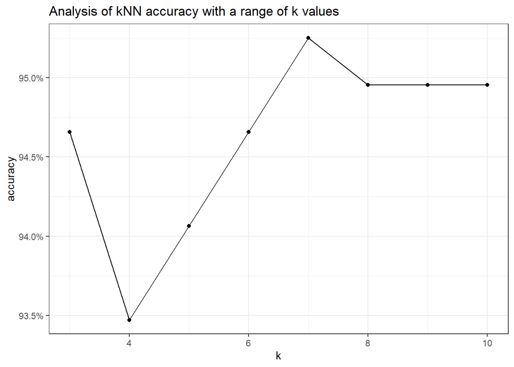

```r
set.seed(-1)
accuracies <- map_df(seq(3,10), function(x) {
  model <- knn(train = df.train[-c(1,2)], # drop status and country
             test = df.val[-c(1,2)], # drop status and country
             cl = factor(df.train$Status), # convert to factor
             k = x)
  list(k = x,
       accuracy = sum(model == factor(df.val$Status))/nrow(df.val))
})
accuracies %>%
  ggplot(aes(x=k, y=accuracy)) +
  geom_point() +
  geom_line() +
  theme_bw() +
  scale_y_continuous(labels=scales::percent) +
  labs(title = "Analysis of kNN accuracy with a range of k values")
```

Out of curiosity, since the recommended value of k is typically the square root of the number of datapoints in the training set, we extend this exercise further:

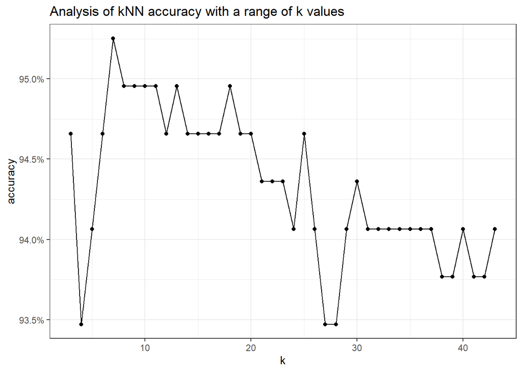

```r
set.seed(-1)
accuracies <- map_df(seq(3,sqrt(nrow(df.train))), function(x) {
  model <- knn(train = df.train[-c(1,2)], # drop status and country
             test = df.val[-c(1,2)], # drop status and country
             cl = factor(df.train$Status), # convert to factor
             k = x)
  list(k = x,
       accuracy = sum(model == factor(df.val$Status))/nrow(df.val))
})
accuracies %>%
  ggplot(aes(x=k, y=accuracy)) +
  geom_point() +
  geom_line() +
  theme_bw() +
  scale_y_continuous(labels=scales::percent) +
  labs(title = "Analysis of kNN accuracy with a range of k values")
```

We can see from both plots that a k value of 7 produces the most accurate prediction, and accuracy trends downward when increasing k from there. This is similar to the k value we selected for our prediction in the previous section. Considering that our sample sizes are 1905 and 337 for the training and validation sets respectively, this relatively small optimal k value indicates that features distinguishing developed versus developing countries are quite distinct. Overall, our model appears to be quite accurate.